# Loans - Final Group Project

Data Detectives

2024-11-21

1. Introduction
   1. Loading the dataset
   2. Pre-processing the data
2. Analysis of the Current Scenario
3. Unsupervised Learning
   1. Split the data
   2. Logistic Regression Model
   3. K-Nearest Neighbor Model
   4. Artificial Neural Network Model
   5. Support Vector Machine Model
   6. Decision Tree Model
   7. Random Forest Model
   8. XGBoost Model
   9. Stack Model
   10. Comparison of the metrics from all models
4. Conclusion
   1. Business Case Conclusion
   2. Lessons Learned and Improvement Points
   3. Overall Project and Course Conclusion

# 1. Introduction: Purpose of the Work

Uncollected loans have historically been one of the primary challenges facing banks and financial institutions, representing a significant source of financial loss. While these businesses profit considerably from interest on loans, they must also bear substantial costs when borrowers fail to repay their debts. These defaults not only strain profitability but also impact operational stability and long-term growth. Addressing this issue has become critical for maintaining financial health and improving lending strategies.

The objective of this work is to build a predictive model to assist banks in mitigating losses associated with uncollected loans. By leveraging historical data, the model aims to predict the likelihood of loan repayment, enabling better decision-making in loan approvals and risk management. With a robust predictive system, banks can improve internal financial planning, reduce exposure to high-risk borrowers, and optimize resource allocation for loan recovery efforts.

The dataset used in this analysis comes from an American financial services business, spanning the period from April 2008 to September 2015. Among its many features, the dataset includes a key variable, `loan_status`, which indicates the repayment status of each loan. Using this and other attributes, the model will help predict whether loans will be repaid or defaulted. This tool not only aids in reducing potential losses but also empowers the company to develop more informed and effective lending policies.

In summary, this report aims to provide a data-driven solution for a pressing issue in the banking sector by building a predictive model for loan analysis. The insights derived from this work will help the business enhance its financial resilience and support better credit risk assessment practices.

## a. Loading the dataset

Before staring with the analysis and the financial calculations, we need to get the data and pre-process it. For organizations sake, all the libraries were called in this first snippet, just so they are not lost or repeated in different parts of the code.

```r
# All Libraries used in this file:

library(dplyr) #For pre-processing transformations
library(ggplot2) # For plotting graphics
library(scales) # For one of the graphics scale
library(caret)  # For Confusion Matrix
library(class)  # For KNN
library(neuralnet) # For ANN
library(kernlab) # For SVM
library(C50) # For Decision Tree
library(randomForest) # For Random Forest
library(xgboost) # For Xgboost
```

The following code demonstrates how to get the data. By using the `stringAsFactors = T` function, the data variables will be read as factors, avoiding a manual transformation of each, as we will need data as factors on further steps of this report. The `str()` and the `summary()` functions were commented due to its length, for organization purposes.

```r
df <- read.csv("final_dataset_loan.csv", stringsAsFactors = T)
#str(df)
#summary(df)
```

## b. Pre-processing the data

#### Converting the Target Variable

As mentioned, the target variable is the `loan_status` of each customer, but as we can see below, there are some of these categories that should be disregarded considering the goal of prediction if the loan is delayed or not.

```r
levels(df$loan_status)
```

```
##  [1] "Charged Off"
##  [2] "Current"
##  [3] "Default"
##  [4] "Does not meet the credit policy. Status:Charged Off"
##  [5] "Does not meet the credit policy. Status:Fully Paid"
##  [6] "Fully Paid"
##  [7] "In Grace Period"
##  [8] "Issued"
##  [9] "Late (16-30 days)"
## [10] "Late (31-120 days)"
```

To ensure the analysis is focused and aligned with the objective of predicting whether loans will be collected or not, certain loan statuses and categories will be excluded from the dataset. Specifically, loans categorized as `Does not meet the credit policy. Status: Fully Paid` and `Does not meet the credit policy. Status: Charged Off` will be removed, as these do not align with the credit policy criteria under consideration. Additionally, loans currently `In Grace Period` and those classified as `Issued` will also be excluded, as they are not actively in the repayment phase and do not provide relevant information for the binary prediction task.

By narrowing the dataset to include only loans that meet the credit policy and are within the payment period, the analysis can focus on predicting loan repayment outcomes effectively. This approach ensures the predictive model is built on a dataset representative of the target scenario, thereby enhancing its reliability and applicability in assessing whether loans will be collected or not.

The following code deletes the rows in which the column `loan_status` is one of the levels we decided to drop:

```r
df <- df[!df$loan_status %in% c("In Grace Period",
                                "Issued",
                                "Does not meet the credit policy. Status:Charged Off",
                                "Does not meet the credit policy. Status:Fully Paid"), ]
```

**Creating the Target Variable:**

With the `loan_status` variable appropriately cleaned, we can now create a binary target variable, `y`. This variable consolidates all “positive” loan statuses into a single positive group and all “negative” loan statuses into a single negative group. By transforming the data into a binary format, the predictive model becomes more straightforward to interpret and implement.

This approach aligns with the primary objective of the analysis: to predict whether a loan will be repaid or not. The binary classification simplifies the predictive process and provides a clear and actionable output for decision-making. By focusing on this streamlined prediction, the model delivers practical insights that support the bank’s goal of efficiently assessing credit risk and optimizing its lending strategy.

```r
df$y <- ifelse(df$loan_status %in% c("Charged Off", "Default", "Late (31-120 days)"), 0, 1)
str(df$y)
```

```
##  num [1:869917] 1 0 1 1 1 1 1 1 0 0 ...
```

As seen, the code below creates a new column `y` on the dataset. Now the target variable is a binary, numeric column.

#### Deleting Columns:

**Meaningless Columns:**

```r
df <- df[, !names(df) %in% c('loan_status', 'url', 'id', 'member_id')]
#str(df)
```

**Future Variables:**

Future variables refer to data that would not be available at the time of making the prediction, such as information about loan repayment or behaviors occurring after the loan is issued. Including these variables can lead to data leakage, where the model uses information it wouldn’t have in real-world scenarios, resulting in overly optimistic performance during training but poor generalization to new data. To prevent this, future variables must be excluded during data pre-processing to ensure the model is trained only on features realistically available at the time of prediction, making it both valid and reliable for practical use.

Here we delete those:

```r
df <- df[, !names(df) %in% c('grade', 'sub_grade','pymnt_plan', 'funded_amnt_inv')]
#str(df)
```

#### Dealing with NaNs:

From the structure of the dataframe, we could see that missing values would appear in two forms: as NaNs (as in columns like `tot_coll_amt`) but also as ” ” or “n/a”. Before handling them, it is important to set a standard. The snippet below puts all missing values under the name `NA` format.

```r
df[df == ""] <- NA
df[df == "n/a"] <- NA
data.frame(colSums(is.na(df)))
```

```
##                             colSums.is.na.df..
## loan_amnt                                    0
## funded_amnt                                  0
## term                                         0
## int_rate                                     0
## installment                                  0
## emp_title                                50394
## emp_length                               43922
## home_ownership                               0
## annual_inc                                   0
## verification_status                          0
## issue_d                                      0
## desc                                    746825
## purpose                                      0
## title                                       33
## zip_code                                     0
## addr_state                                   0
## dti                                          0
## delinq_2yrs                                  0
## earliest_cr_line                             0
## inq_last_6mths                               0
## mths_since_last_delinq                  446356
## mths_since_last_record                  736330
## open_acc                                     0
## pub_rec                                      0
## revol_bal                                    0
## revol_util                                 457
## total_acc                                    0
## initial_list_status                          0
## out_prncp                                    0
## out_prncp_inv                                0
## total_pymnt                                  0
## total_pymnt_inv                              0
## total_rec_prncp                              0
## total_rec_int                                0
## total_rec_late_fee                           0
## recoveries                                   0
## collection_recovery_fee                      0
## last_pymnt_d                              9023
## last_pymnt_amnt                              0
```

[output cut: 13 more lines]

```
## open_il_6m                              856629
## open_il_12m                             856629
## open_il_24m                             856629
## mths_since_rcnt_il                      856983
## total_bal_il                            856629
## il_util                                 858308
## open_rv_12m                             856629
## open_rv_24m                             856629
## max_bal_bc                              856629
## all_util                                856629
## total_rev_hi_lim                         67461
## inq_fi                                  856629
## total_cu_tl                             856629
## inq_last_12m                            856629
## y                                            0
```

Given the substantial number of predictive columns in the dataset, we opted to remove any columns with more than 10% missing values. When the proportion of missing data is too high, imputation methods become less reliable and may introduce unnecessary bias into the dataset. By excluding these columns, we aim to preserve the integrity of the analysis and ensure the predictive model is built on robust and trustworthy data.

```r
threshold <- 0.1
na_percentage <- data.frame((colSums((is.na(df))/nrow(df))))

df <- df[, na_percentage <= threshold]
```

Once we have deleted all the columns that have more than 10% of missing values, lets see if there are any NaNs remaining:

```r
missing_values <- sum(is.na(df))
```

Currently, there are 306319 missing values in the dataset that need to be addressed. The approach to handling missing values differs between numerical and categorical variables, so each will be treated separately to ensure an appropriate and effective imputation strategy:

```r
colSums(is.na(df))
```

```
##                  loan_amnt                funded_amnt
##                          0                          0
##                       term                   int_rate
##                          0                          0
##                installment                  emp_title
##                          0                      50394
##                 emp_length             home_ownership
##                      43922                          0
##                 annual_inc        verification_status
##                          0                          0
##                    issue_d                    purpose
##                          0                          0
##                      title                   zip_code
##                         33                          0
##                 addr_state                        dti
##                          0                          0
##                delinq_2yrs           earliest_cr_line
##                          0                          0
##             inq_last_6mths                   open_acc
##                          0                          0
##                    pub_rec                  revol_bal
##                          0                          0
##                 revol_util                  total_acc
##                        457                          0
##        initial_list_status                  out_prncp
##                          0                          0
##              out_prncp_inv                total_pymnt
##                          0                          0
##            total_pymnt_inv            total_rec_prncp
##                          0                          0
##              total_rec_int         total_rec_late_fee
##                          0                          0
##                 recoveries    collection_recovery_fee
##                          0                          0
##               last_pymnt_d            last_pymnt_amnt
##                       9023                          0
##         last_credit_pull_d collections_12_mths_ex_med
##                         51                         56
##                policy_code           application_type
##                          0                          0
##             acc_now_delinq               tot_coll_amt
##                          0                      67461
##                tot_cur_bal           total_rev_hi_lim
##                      67461                      67461
##                          y
##                          0
```

For the numerical variables, the initial plan was to replace missing values with the column’s median, as this is a common and robust imputation method. However, this approach can still introduce some degree of bias into the dataset. Given the large number of observations available, we determined that the potential risk of bias outweighs the benefit of retaining rows with missing values. Instead, we opted to remove rows with missing numerical values, as this approach ensures data integrity while still leaving a sufficient number of observations to build reliable and effective predictive models.

```r
df <- df %>%
  filter(across(where(is.numeric), ~ !is.na(.)))
#str(df)
```

For the categorical variables, rather than deleting rows with missing values, we opted to create a new category labeled “Unknown.” This approach retains all observations while preserving the dataset’s completeness, ensuring that no potentially valuable information is lost. By assigning missing values to the “Unknown” category, we can account for their presence in the analysis without introducing bias or distortion, allowing the predictive model to handle these cases effectively.

```r
df <- df %>%
  mutate(across(c("emp_title", "emp_length", "title", "last_pymnt_d", "last_credit_pull_d"), ~ ifelse(is.na(.), "Unkown", .)))

# the function above transformed these columns into characters, sowe are just going to transform back to factors
df <- df %>%
  mutate(across(where(is.character), as.factor))
```

To ensure that all missing values have been properly handled, the following code snippet counts the `NA` values across the entire dataset:

```r
final_missing_values <- sum(is.na(df))
cat("Total missing values in the dataset:", final_missing_values, "\n")
```

```
## Total missing values in the dataset: 0
```

#### Addressing factor columns with too many levels:

For models such as Logistic Regression, KNN, ANN, and SVM, the data needs to be encoded or dummified (a process explained later). This involves creating a separate column for each level of every categorical variable. However, some factors in the dataset have an excessively high number of levels, which can make the models computationally expensive and inefficient.

To address this, we decided to set these high-cardinality variables to `NULL`, effectively excluding them from the analysis. While these variables may have some predictive power, the dataset contains sufficient remaining predictors to build accurate models without them. It is worth noting that in scenarios where computational power is not a limitation, this step could be skipped, and all variables could be included for a potentially more comprehensive analysis.

```r
df$emp_title <- NULL
df$title <- NULL
df$issue_d  <- NULL
df$addr_state <- NULL
df$zip_code <- NULL
df$earliest_cr_line <- NULL
df$last_pymnt_d <- NULL
df$last_credit_pull_d <- NULL
```

#### Getting a random sample of 10% of the dataset:

After addressing the dataset’s issues and ensuring it is properly treated, we decided to proceed with a random sample of 10% of the rows from the dataset. This step was introduced to accommodate current computational limitations, ensuring the modeling process remains efficient and manageable. However, it is important to note that in scenarios where computational resources are not a constraint, this step can be entirely skipped, allowing the full dataset to be utilized for potentially more robust model training.

Here, we considered creating a balanced random sample, consisting of 50% random samples from negative cases (defaulted loans) and 50% random samples from positive cases (repaid loans). While this approach could potentially improve the performance of models that struggle with imbalanced datasets, we decided against it. Balancing the dataset artificially could misrepresent the actual distribution of the target variable and complicate the model’s predictions on new, real-world data, where the distribution will remain imbalanced. By retaining the original distribution, we ensure the model’s performance and predictions remain realistic and applicable to the actual business context.

```r
sample_size <- 0.1
set.seed(12345)
sample_rows <- sample(1:nrow(df), sample_size*nrow(df))
sample_data <- df[sample_rows, ]
#str(sample_data)
```

#### Encoding Categorical Variables:

As mentioned earlier, most of the models we will be using cannot handle categorical columns with more than two levels (i.e., non-binary categorical variables). To address this, we encode the dataset to transform these categorical variables into a format that the models can process effectively.

This encoding process, known as dummification or one-hot encoding, converts each level of a categorical variable into its own separate column. For example, the `home_ownership` variable is transformed into new columns such as `ANY`, `MORTGAGE`, `OWN`, etc., with each row indicating the presence or absence of a specific level. Importantly, the encoding process excludes one column for each factor, which prevents issues with multicollinearity by avoiding redundant information. This ensures the dataset is both interpretable and compatible with the predictive models we are implementing.

```r
encoded_data <- as.data.frame(model.matrix(~ . -1, sample_data))
#str(encoded_data)
#summary(encoded_data)

# To make the term 36/60 months without " "
colnames(encoded_data) <- make.names(colnames(encoded_data))

# Delete cuz is either all 0 or all 1s
encoded_data$purposeeducational <- NULL
encoded_data$policy_code <- NULL
```

Finally, the last step of cleaning is scaling our data. Further on in our analysis, we will build models such as a KNN and a ANN; for these models, our numeric factors have to be comparable to one another. For this to happen, they have to be on the same scale, so we create a separate variable that contains scaled data for the those models. We utilize min max scaling in this instance, so each numeric variable is now on a scale of 0-1.

```r
minmax <- function(x) {
  (x - min(x)) / (max(x)-min(x))
}
scaled_data <- as.data.frame(lapply(encoded_data, minmax))
```

**Business Note:** The data preparation process outlined above involved extensive steps to clean and structure the dataset for the upcoming analysis. While understanding these steps is not essential from a business perspective, it is important to note that the data has been thoroughly cleaned and prepared to ensure the analysis is accurate, reliable, and aligned with the project’s objectives.

# 2. Analysis of the Current Scenario

**Business Note:** Before building the predictive models, this section will focus on understanding the current scenario of the firm and its loans. We will conduct some preliminary analyses to evaluate client behaviors and examine potential correlations with loan statuses. These insights will provide context for the predictive modeling process and may highlight key factors influencing loan outcomes.

On this following graph we can see the distribution of the target variable.

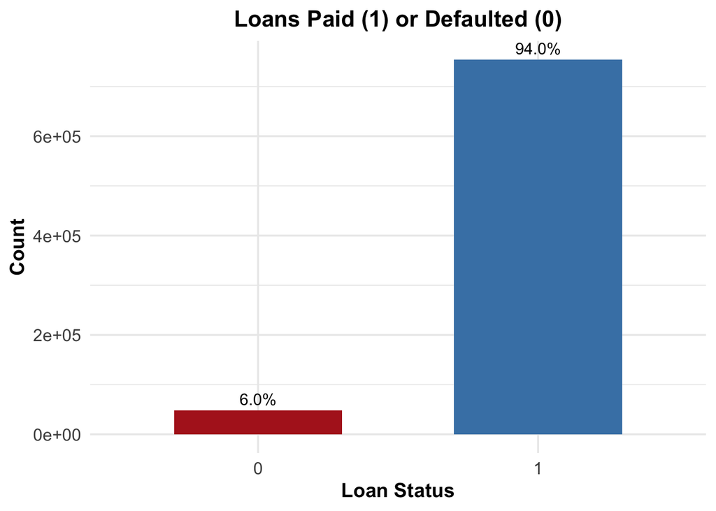

**Business Note:** The graphic below depicts the bank’s current customer default distribution with approximately 6% of individuals defaulting on their loans while 94% do not. Although the percentage of defaulters appears small, the financial impact on the bank is notably significant.

The following graph aims to provide a clear and straightforward representation of the company’s current scenario. To create this visual, calculations on revenue and losses were performed, offering an overview of the financial impact of collected and uncollected loans. This helps to contextualize the firm’s situation before diving into more detailed analyses.

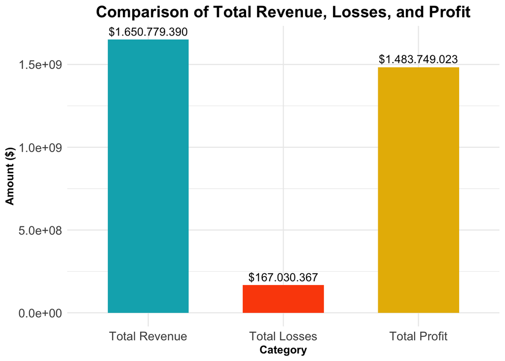

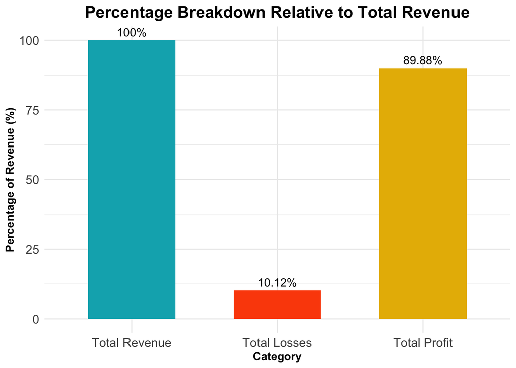